# Overview

#### Common Values

| Value | Count | Frequency (%) |
| --- | --- | --- |
| C23 C25 C27 | 4 | 0.4% |
| G6 | 4 | 0.4% |
| B96 B98 | 4 | 0.4% |
| C22 C26 | 3 | 0.3% |
| D | 3 | 0.3% |
| F33 | 3 | 0.3% |
| E101 | 3 | 0.3% |
| F2 | 3 | 0.3% |
| B20 | 2 | 0.2% |
| E67 | 2 | 0.2% |
| Other values (137) | 173 | 19.4% |
| (Missing) | 687 | 77.1% |

#### Length

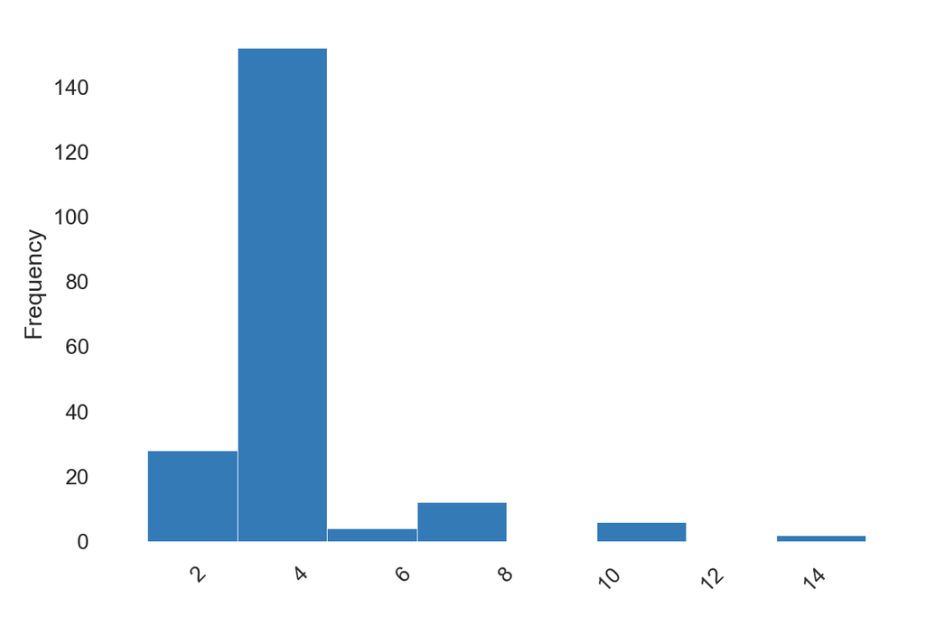

Histogram of lengths of the category

**Words**

| Value | Count | Frequency (%) |
| --- | --- | --- |
| c23 | 4 | 1.7% |
| c27 | 4 | 1.7% |
| g6 | 4 | 1.7% |
| b96 | 4 | 1.7% |
| b98 | 4 | 1.7% |
| f | 4 | 1.7% |
| c25 | 4 | 1.7% |
| f33 | 3 | 1.3% |
| e101 | 3 | 1.3% |
| f2 | 3 | 1.3% |
| Other values (151) | 201 | 84.5% |

**Characters**

**Characters**

#### Most occurring characters

| Value | Count | Frequency (%) |
| --- | --- | --- |
| 2 | 72 | 9.8% |
| C | 71 | 9.7% |
| B | 64 | 8.7% |
| 1 | 61 | 8.3% |
| 3 | 59 | 8.1% |
| 6 | 51 | 7.0% |
| 5 | 45 | 6.1% |
| 4 | 37 | 5.1% |
| 8 | 37 | 5.1% |
|  | 34 | 4.6% |
| Other values (9) | 201 | 27.5% |

**Categories**

#### Most occurring categories

| Value | Count | Frequency (%) |
| --- | --- | --- |
| Decimal Number | 460 | 62.8% |
| Uppercase Letter | 238 | 32.5% |
| Space Separator | 34 | 4.6% |

#### Most frequent character per category

##### *Decimal Number*

| Value | Count | Frequency (%) |
| --- | --- | --- |
| 2 | 72 | 15.7% |
| 1 | 61 | 13.3% |
| 3 | 59 | 12.8% |
| 6 | 51 | 11.1% |
| 5 | 45 | 9.8% |
| 4 | 37 | 8.0% |
| 8 | 37 | 8.0% |
| 7 | 34 | 7.4% |
| 9 | 33 | 7.2% |
| 0 | 31 | 6.7% |

##### *Uppercase Letter*

| Value | Count | Frequency (%) |
| --- | --- | --- |
| C | 71 | 29.8% |
| B | 64 | 26.9% |
| D | 34 | 14.3% |
| E | 33 | 13.9% |
| A | 15 | 6.3% |
| F | 13 | 5.5% |
| G | 7 | 2.9% |
| T | 1 | 0.4% |

##### *Space Separator*

| Value | Count | Frequency (%) |
| --- | --- | --- |
|  | 34 | 100.0% |

**Scripts**

#### Most occurring scripts

| Value | Count | Frequency (%) |
| --- | --- | --- |
| Common | 494 | 67.5% |
| Latin | 238 | 32.5% |

#### Most frequent character per script

##### *Common*

| Value | Count | Frequency (%) |
| --- | --- | --- |
| 2 | 72 | 14.6% |
| 1 | 61 | 12.3% |
| 3 | 59 | 11.9% |
| 6 | 51 | 10.3% |
| 5 | 45 | 9.1% |
| 4 | 37 | 7.5% |
| 8 | 37 | 7.5% |
|  | 34 | 6.9% |
| 7 | 34 | 6.9% |
| 9 | 33 | 6.7% |

##### *Latin*

| Value | Count | Frequency (%) |
| --- | --- | --- |
| C | 71 | 29.8% |
| B | 64 | 26.9% |
| D | 34 | 14.3% |
| E | 33 | 13.9% |
| A | 15 | 6.3% |
| F | 13 | 5.5% |
| G | 7 | 2.9% |
| T | 1 | 0.4% |

**Blocks**

#### Most occurring blocks

| Value | Count | Frequency (%) |
| --- | --- | --- |
| ASCII | 732 | 100.0% |

#### Most frequent character per block

##### *ASCII*

| Value | Count | Frequency (%) |
| --- | --- | --- |
| 2 | 72 | 9.8% |
| C | 71 | 9.7% |
| B | 64 | 8.7% |
| 1 | 61 | 8.3% |
| 3 | 59 | 8.1% |
| 6 | 51 | 7.0% |
| 5 | 45 | 6.1% |
| 4 | 37 | 5.1% |
| 8 | 37 | 5.1% |
|  | 34 | 4.6% |
| Other values (9) | 201 | 27.5% |

Embarked  
Categorical

`HIGH CORRELATION`

| Distinct | 3 |
| --- | --- |
| Distinct (%) | 0.3% |
| Missing | 2 |
| Missing (%) | 0.2% |
| Memory size | 50.5 KiB |

| S | 644 |
| --- | --- |
| C | 168 |
| Q | 77 |

**Overview**

Length

| Max length | 1 |
| --- | --- |
| Median length | 1 |
| Mean length | 1 |
| Min length | 1 |

Characters and Unicode

| Total characters | 889 |
| --- | --- |
| Distinct characters | 3 |
| Distinct categories | 1 [?](https://en.wikipedia.org/wiki/Unicode_character_property#General_Category) |
| Distinct scripts | 1 ? |
| Distinct blocks | 1 [?](https://en.wikipedia.org/wiki/Unicode_block) |

The Unicode Standard assigns character properties to each code point, which can be used to analyse textual variables.

Unique

| Unique | 0 ? |
| --- | --- |
| Unique (%) | 0.0% |

Sample

| 1st row | S |
| --- | --- |
| 2nd row | C |
| 3rd row | S |
| 4th row | S |
| 5th row | S |

**Categories**